# Novena sesión

**Elaborado por Chiara Zamora**

PCPOCZAM@upc.edu.pe

Veremos:

**Estadística univariada**

1. Importación y limpieza de datos
2. Tablas de frecuencia
3. Medidas de tendencia central
4. Medidas de dispersión
5. Medidas de posición
6. Medidas de simetría

### **1. Importación de datos**

Utilizaremos el conjunto de datos data que hace referencia a población en proceso migratorio.

- Ruta

```r
#install.packages("rio")

library(rio)
data = import("https://github.com/ChiaraZamoraM/Stats_UPC/raw/main/Databases/migration.xlsx")
```

- Exploración del dataframe

```r
dim(data)
```

```
## [1] 400   8
```

```r
names(data)
```

```
## [1] "Edad"              "Sexo"              "Embarazada"
## [4] "Estudios"          "Documento"         "Fecha_llegada"
## [7] "Cantidad_dias"     "Dinero_disponible"
```

```r
str(data)
```

```
## 'data.frame':    400 obs. of  8 variables:
##  $ Edad             : num  46 22 35 39 45 60 30 39 18 33 ...
##  $ Sexo             : chr  "Masculino" "Femenino" "Femenino" "Masculino" ...
##  $ Embarazada       : chr  NA "no" "no" NA ...
##  $ Estudios         : chr  "secundaria_bach_completa" "tecnicosuperiorcompleto" "universitariocompleto" "secundaria_bach_completa" ...
##  $ Documento        : chr  "pasaporte" "pasaporte" "pasaporte" "pasaporte" ...
##  $ Fecha_llegada    : POSIXct, format: "2019-07-12" "2019-06-22" ...
##  $ Cantidad_dias    : num  5 25 17 1 23 0 12 22 25 24 ...
##  $ Dinero_disponible: num  130 29 71 124 31 117 94 34 32 36 ...
```

```r
str(data$Fecha_llegada)
```

```
##  POSIXct[1:400], format: "2019-07-12" "2019-06-22" "2019-06-30" "2019-07-16" "2019-06-24" ...
```

```r
data$Fecha_llegada=as.character(data$Fecha_llegada)
```

```r
which(is.na(data))
```

```
##   [1]  801  804  805  806  809  810  811  812  813  814  815  816  817  822  824
##  [16]  827  830  831  833  840  841  842  845  847  848  849  850  852  854  855
##  [31]  858  859  861  863  865  867  870  872  873  879  880  882  883  884  888
##  [46]  889  891  892  893  894  895  896  897  898  901  902  909  913  914  916
##  [61]  918  919  920  921  922  925  927  932  934  935  936  937  938  941  954
##  [76]  955  956  957  961  965  968  969  970  972  974  975  980  983  988  989
##  [91]  991  992  993  995  997 1001 1002 1013 1015 1017 1019 1023 1030 1034 1035
## [106] 1036 1039 1041 1043 1047 1048 1049 1051 1052 1053 1054 1058 1061 1065 1070
## [121] 1071 1073 1078 1081 1090 1093 1097 1100 1103 1112 1116 1117 1126 1129 1131
## [136] 1136 1139 1141 1142 1149 1150 1151 1154 1157 1163 1164 1169 1170 1173 1174
## [151] 1176 1179 1182 1184 1191
```

### **2. Tablas de frecuencia**

#### **Simple o absoluta**

```r
documento = data$Documento
```

```r
tabla1 = table(data$Documento)
```

Visualizamos…

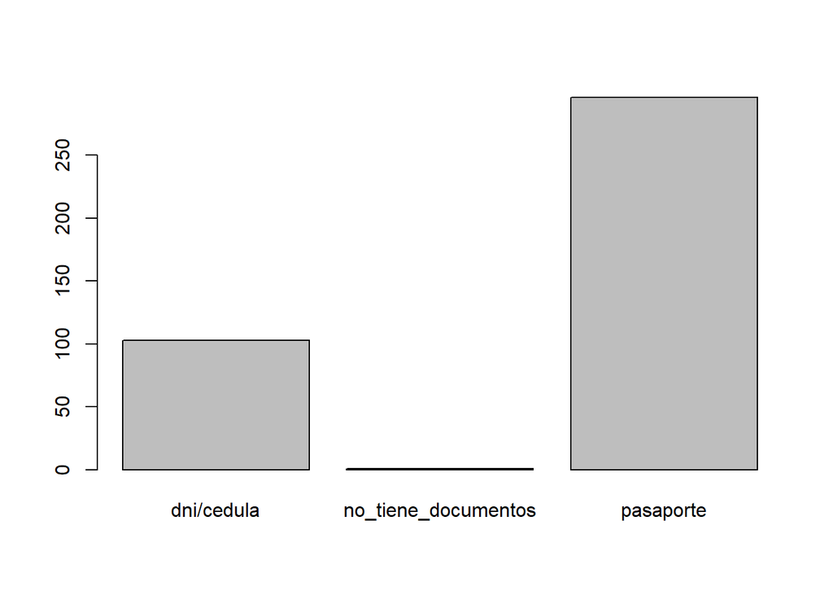

```r
barplot(tabla1)
```

### **Relativa**

```r
prop.table(tabla1)*100
```

```
##
##          dni/cedula no_tiene_documentos           pasaporte
##               25.75                0.25               74.00
```

Practiquemos…

- De frecuencias simples/absolutas

```r
table(data$Sexo)
```

```
##
##  Femenino Masculino
##       245       155
```

- De frecuencias relativas

```r
100*prop.table(table(data$Sexo))
```

```
##
##  Femenino Masculino
##     61.25     38.75
```

##### Uso de **attach**

```r
attach(data) #me sirve para llamar a mi variable sin necesidad del signo de $
Documento
```

[output not shown]

[output cut: 119 more lines]

```r
detach(data) #cancela el attach
#Documento
```

```r
head(data$Documento)
```

```
## [1] "pasaporte" "pasaporte" "pasaporte" "pasaporte" "pasaporte" "pasaporte"
```

También podemos usar la función **freq** del paquete…

- **descr**

```r
library(descr) #voy a tener porcentaje válido que no considera NA's
#detach("package:descr", unload = TRUE)#desconectar el paquete
```

```r
tabla2 = freq(data$Estudios, plot=F) #combinación de table con prop.table
```

```r
tabla2
```

```
## data$Estudios
##                            Frequency Percent
## ninguno                            2    0.50
## posgradocompleto                   3    0.75
## primariacompleta                  11    2.75
## secundaria_bach_completa         168   42.00
## secundaria_bach_incompleta        27    6.75
## tecnicomediocompleto              23    5.75
## tecnicomedioincompleto             4    1.00
## tecnicosuperiorcompleto           48   12.00
## tecnicosuperiorincompleto          3    0.75
## universitariocompleto             91   22.75
## universitarioincompleto           20    5.00
## Total                            400  100.00
```

- **Summarytools**

```r
#install.packages("summarytools")
library(summarytools) #voy a tener porcentaje válido que no considera NA's
tabla3 = summarytools::freq(data$Documento)
```

### **3. Medidas de tendencia central**

#### **Media**

```r
mean(data$Edad)
```

```
## [1] 34.675
```

```r
mean.default(data$Edad, na.rm = TRUE)
```

```
## [1] 34.675
```

#### **Media recortada**

Recortamos el 10% de las observaciones de cada extremo.

```r
mean.default(data$Edad, na.rm = TRUE, trim = 0.1)
```

```
## [1] 33.475
```

#### **Mediana**

```r
median(data$Dinero_disponible)
```

```
## [1] 71
```

```r
median.default(data$Dinero_disponible, na.rm = TRUE)
```

```
## [1] 71
```

#### **Moda**

```r
#install.packages("modeest")
library(modeest)
```

```r
mfv(data$Edad)
```

```
## [1] 25
```

### **4. Medidas de posición**

#### **Cuartiles**

```r
quantile(data$Edad, prob = c(0.25, 0.5, 0.75), na.rm = TRUE)
```

```
##  25%  50%  75%
## 26.0 32.5 40.0
```

#### **Quintiles**

```r
quantile(data$Edad, c(0.2, 0.4, 0.6, 0.8), na.rm = TRUE)
```

```
## 20% 40% 60% 80%
##  25  30  35  43
```

#### **Percentiles**

Obtenemos el percentil 93.

```r
quantile(data$Edad, c(0.93), na.rm = TRUE)
```

```
##   93%
## 54.07
```

#### Visualización: **Boxplot o diagrama de cajas**

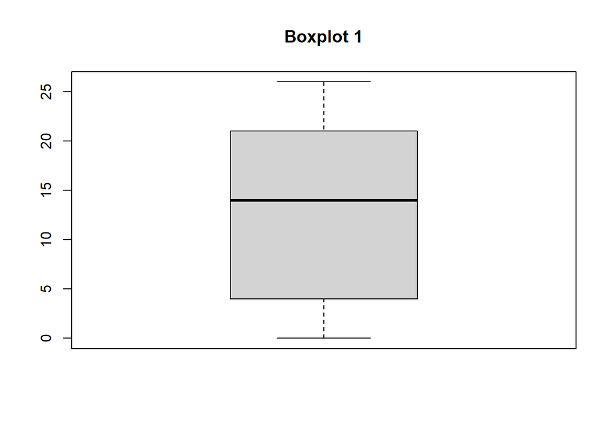

```r
boxplot(data$Cantidad_dias,
        main = "Boxplot 1",
        outline = TRUE)
```

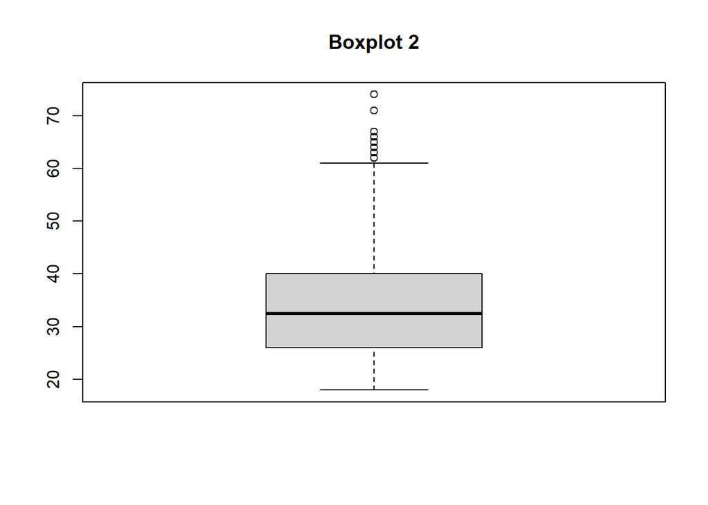

```r
boxplot(data$Edad,
        main = "Boxplot 2",
        outline = TRUE)
```

### **5. Medidas de dispersión**

#### **Rango**

```r
range(data$Edad, na.rm = TRUE)
```

```
## [1] 18 74
```

```r
min(data$Edad, na.rm = TRUE)
```

```
## [1] 18
```

```r
max(data$Edad, na.rm = TRUE)
```

```
## [1] 74
```

#### **Rango intercuartílico**

Diferencia entre el Q1(primer cuartil) y Q3(tercer cuartil).

El 50% de los datos está dentro de este rango.

```r
IQR(data$Cantidad_dias)
```

```
## [1] 17
```

#### **Varianza**

```r
var(data$Edad, na.rm = TRUE)
```

```
## [1] 129.7337
```

#### **Desviación estándar**

```r
sd(data$Edad, na.rm = TRUE)
```

```
## [1] 11.39007
```

#### **Coeficiente de variación**

Desviación estándar entre la media.

Nos permite comparar la dispersión entre dos muestras.

Datos más homogéneos cercanos a ceros.

```r
n=50

muestra1= sample(1:nrow(data),size=n,replace=FALSE)

data1= data[muestra1, ]

cv1=sd(data1$Edad)/mean(data$Edad)
```

```r
muestra2= sample(1:nrow(data),size=n,replace=FALSE)

data2= data[muestra2, ]

cv2= sd(data2$Edad)/mean(data$Edad)
```

```r
cv1
```

```
## [1] 0.2923142
```

```r
cv2
```

```
## [1] 0.3503873
```

### **6. Medidas de simetría**

#### Visualización: **Histograma**

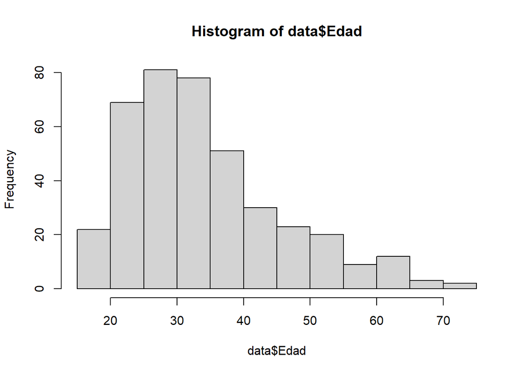

```r
hist(data$Edad)
```

#### **Asimetría**

1. Asimetría Negativo
- Gráfica hacia la izquierda.
- Media < mediana < moda.
- SK < 0
2. Simétrico
- Coincide la media, mediana y moda en un mismo punto.
- SK = 0
3. Asimetría Positiva
- Gráfico hacia la derecha.
- Media > mediana > moda.
- SK > O

```r
library(moments)
skewness(data$Edad)
```

```
## [1] 0.9451887
```

#### **Curtosis**

1. Leptocúrtico
- K > 0
2. Mesocúrtico
- K = 0

c.Platicúrtico

- K < 0

```r
library(moments)
kurtosis(data$Edad)
```

```
## [1] 3.475709
```